# Advanced PRS and Summary Statistics Analyses

Nicholas Mancuso and Sylvia Shen

6/12/2024

## 1. Overview

Large-scale GWAS for thousands of molecular phenotypes (e.g., metabolites, plasma proteins, lipids) have identified genetic variants that associate with “expression” suggesting partial genetic control. Given the complex regulatory network underlying molecular phenotypes, we expect widespread vertical and horizontal pleiotripy for variants with regulatory evidence.

### 1.1 Goals

1. Here, we aim to leverage this widespread pleiotropy to identify shared genetic components across many molecular phenotypes using summary statistics. $\newcommand{\bG}{\mathbf{G}}$ $\newcommand{\bX}{\mathbf{X}}$ $\newcommand{\bz}{\mathbf{z}}$ $\newcommand{\by}{\hat{\mathbf{y}}}$ $\newcommand{\bbeta}{\boldsymbol{\beta}}$ $\newcommand{\balpha}{\boldsymbol{\alpha}}$ $\newcommand{\bbetahat}{\hat{\boldsymbol{\beta}}}$ $\newcommand{\balphahat}{\hat{\boldsymbol{\alpha}}}$ $\newcommand{\bBhat}{\hat{\mathbf{B}}}$ $\newcommand{\bD}{\mathbf{D}}$ $\newcommand{\bU}{\mathbf{U}}$ $\newcommand{\bV}{\mathbf{V}}$ $\newcommand{\bS}{\mathbf{S}}$ $\newcommand{\bI}{\mathbf{I}}$ $\newcommand{\bZ}{\mathbf{Z}}$

### 1.2 Truncated Singular Value Decomposition

Let $\bX$ be an $n \times p$ matrix. We can write the singular value decomposition (SVD) as $\bX = \bU \bS \bV^T$ where $\bU$ is an $n \times n$ orthonormal matrix (i.e. $\bU\bU^T = \bI_n$), $\bS$ is an $n \times p$ rectangular diagonal matrix where $\bS_{ii} \geq 0$ are the *singular values*, and $\bV$ is an $p \times p$ orthonormal matrix (i.e. $\bV\bV^T = \bI_p$). Note that columns of $\bU$ are the eigenvectors of $\bX\bX^T$ and columns of $\bV$ are the eigenvectors of $\bX^T \bX$ (NB: learn more about PCA in upcoming session with Dr. Siegmund).

In practice we are only interested in the first few components of $\bU, \bV$ and wish to compute the *truncated* SVD (tSVD) as $\bX \approx \bU_t \bS_t \bV^T_t$ where we restrict to the first $t$ singular values of $\bU, \bS, \bV$. This results in a rank-$t$ approximation to $\bX$ (the best rank-$t$ approximation under Frobenius Norm).

Computing the SVD requires time $O(\text{min}(np^2, n^2p))$ which can be costly for large $n,p$. Specialized algorithms (e.g., Lanczos, randomized projections/sketches) for tSVD run much faster than naive approach when $t \ll \text{min}(n, p)$.

### 1.3 Decomposition of Genetic Associations (DeGAs; tSVD) for GWAS summary data

[Tanigawa et al. Nat Comms 2019](https://www.nature.com/articles/s41467-019-11953-9) describe an approach for tSVD on summary statistics, which we will briefly describe here. Let $\bZ$ be the $k \times p$ GWAS Z-score matrix (i.e. Wald statistic) for $k$ phenotypes across $p$ SNPs. We can center each column and standardize by its standard deviation to obtain the mean-centered and standardized matrix $\tilde{\bZ}$. Computing the tSVD for $\tilde{\bZ} = \bU_t \bS_t \bV^2_t$ gives us a low-rank representation of our data and provides a means to assess shared/independent genetic components across phenotypes.

### 1.4 Data Description

Here we will be investigating curated summary statistics on from 158 serum metabolites measured in 6263 men recruited for the Metabolic Syndrom in Men (METSIM) cohort reported in [Gallois et al Nat Comms 2019](https://www.nature.com/articles/s41467-019-12703-7).

Gallois et al reported 588 significant associations in at least one metabolite, of which we have pruned for LD resulting in associations across 290 variants for 158 metabolites.

We aim to identify shared genetic components across these 158 metabolites using their respective GWAS summary data and tSVD.

## Loading the GWAS summary data

Let’s load the prepared, cleaned GWAS results for the 158 metabolites and effect-szies corresponding to 290 SNPs. We’ll first construct Z-scores based on Wald statistics and characterize the number of approximately independent hits per metabolite, as well as plot the distribution of Z-scores at these SNP/metabolite pairs.

```r
load("AdvSumStats.RData")

# we should have three variables corresponding to: beta_hats, variances, and
# metabolite names
ls()
```

```
## [1] "df_beta"     "metab_names" "old.warn"    "var_beta"
```

```r
# data frame with metabolites names
df_metab <- tibble(metab = metab_names)

# calculate Z-scores based on Wald statistics
# (rows are SNPs and columns are metabolites)
Z <- df_beta / sqrt(var_beta)

# data frame with each SNP's Z-scores
df_Z <- Z %>%
  rownames_to_column %>%
  as_tibble %>%
  rename(snp = rowname)

# ~ 10 metabolites don't exhibit true GWS signal, but this is due to our
# selection of SEs based on standard test, compared with CMS test reported in study
df_lz <- df_Z %>%
  pivot_longer(-snp, names_to="metab", values_to="zscore")

# count the number of significant SNP associations for each metabolite
df_lz %>%
  mutate(p.value = 2 * pnorm(abs(zscore), lower.tail=FALSE)) %>%
  group_by(metab) %>%
  summarize(NSig = sum(p.value <= 5e-8)) %>%
  arrange(-NSig)
```

| metab | NSig |
| --- | --- |
| Remnant_C | 11 |
| ApoB_ApoA1 | 10 |
| IDL_FC | 10 |
| IDL_P | 10 |
| S_VLDL_CE | 10 |
| ApoB | 9 |
| IDL_L | 9 |
| S_VLDL_C | 9 |
| VLDL_C | 9 |
| XS_VLDL_L | 9 |

[output cut: 148 more lines]

Let’s create a figure to see the overall distribution of Z-scores in our data.

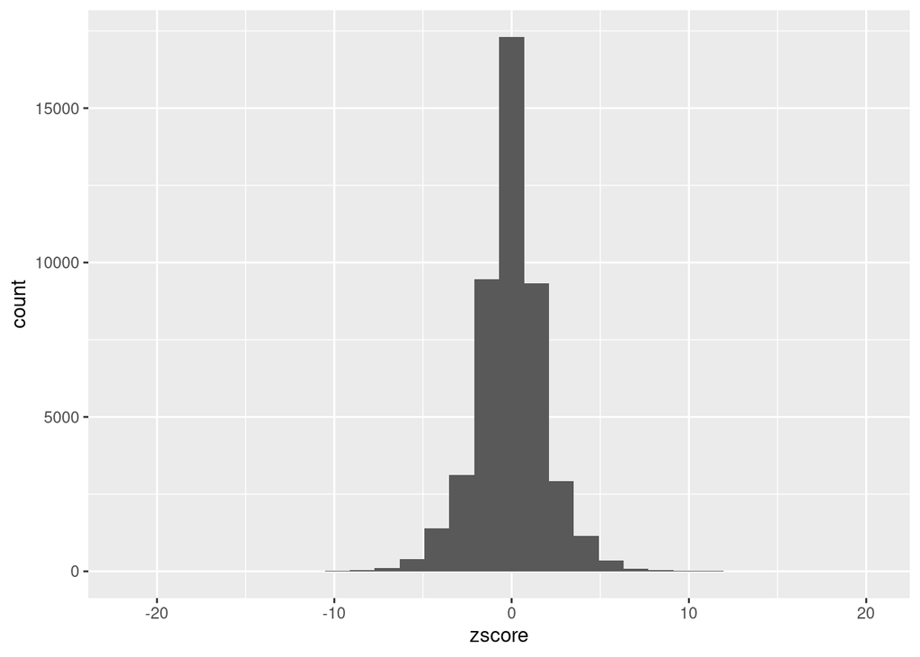

```r
ggplot(df_lz, aes(zscore)) + geom_histogram()
```

### 1.4 Characterizing correlation structure and shared latent components

We’ll use the `corrplot` package to plot the overall correlational structure in our effect-sizes / Z-scores. Ultimately, we see an extreme amount of structure that primarily reflects HDL/LDL/VLDL groups.

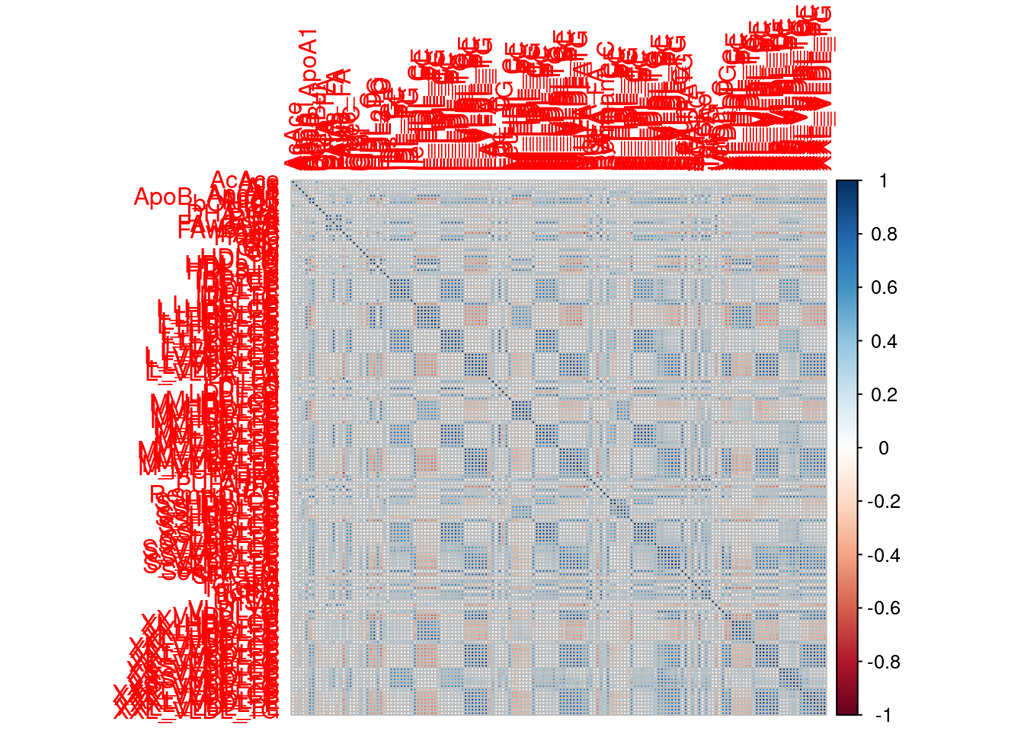

```r
corrplot::corrplot(cor(as.matrix(Z)))
```

```r
# mean-center and standardize our data. this is done to ensure that each
# snp is 'treated equally' in our decomposition, otherwise highly variable
# columns will dominate; take transpose so we scale by SNP.
Ztilde <- scale(t(Z))

# rsvd: Randomized Singular Value Decomposition
tsvd <- rsvd::rsvd(Ztilde, 4)

mat_u <- tsvd$u
colnames(mat_u) <- paste0("PC", 1:4)
mat_v <- tsvd$v
colnames(mat_v) <- paste0("PC", 1:4)


df_u <- bind_cols(tibble(metab = rownames(Ztilde)), as_tibble(mat_u))
df_v <- bind_cols(tibble(snp = colnames(Ztilde)), as_tibble(mat_v))
```

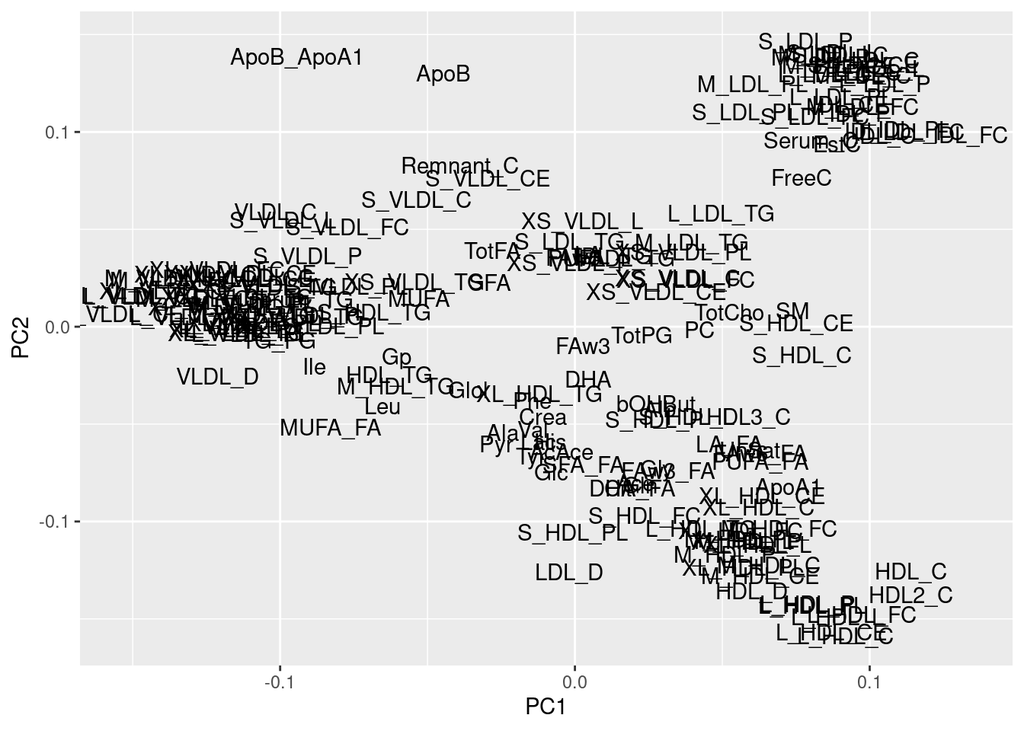

```r
ggplot(df_u, aes(PC1, PC2, label=metab)) + geom_text()
```

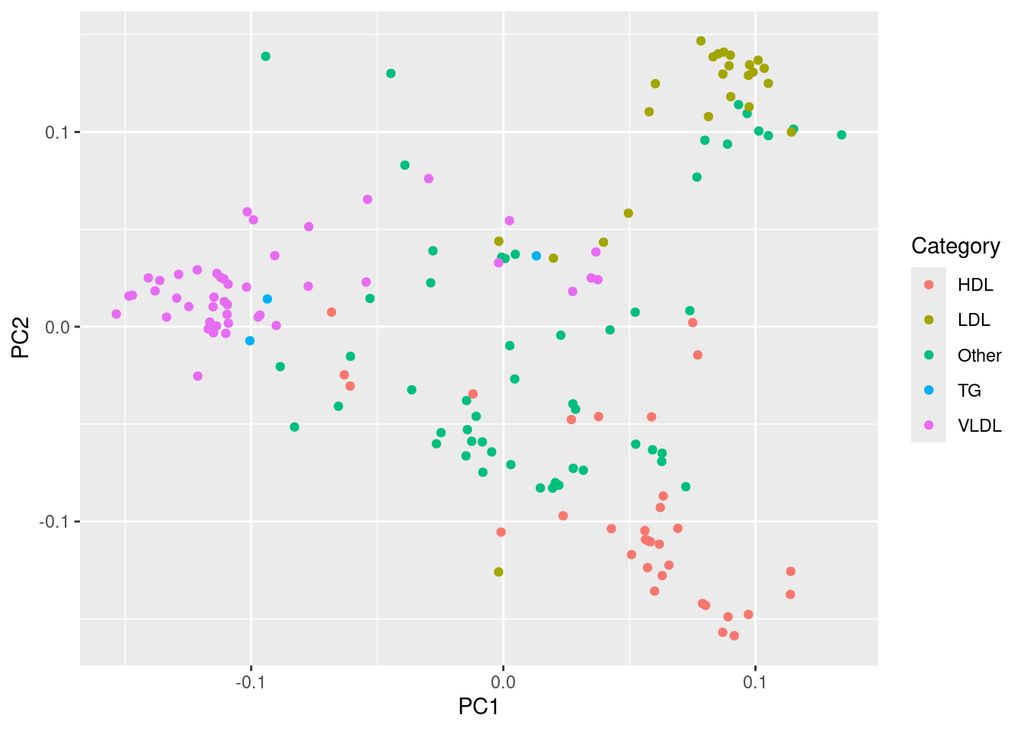

```r
# create broad categories
df_u <- df_u %>% mutate(Category = ifelse(grepl("VLDL", metab), "VLDL",
                                   ifelse(grepl("LDL", metab) & !grepl("VLDL", metab), "LDL",
                                   ifelse(grepl("HDL", metab), "HDL",
                                          ifelse(grepl("TG", metab), "TG", "Other")))))

# replot
ggplot(df_u, aes(PC1, PC2, color=Category, group=Category)) + geom_point()
```

We can also plot the principal components for variants to get a sense of which SNPs affect many phenotypes.

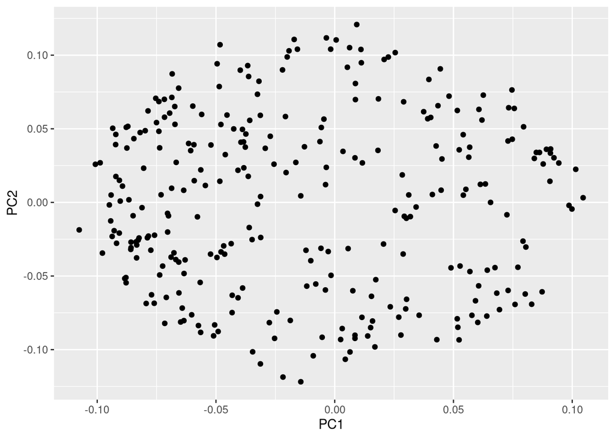

```r
ggplot(df_v, aes(PC1, PC2, label=snp)) + geom_point()
```